# Parte 3: Slot Machine

## **Capìtulo 7:** Programs

El siguiente còdigo genera tres sìmbolos comunes en este tipo de juegos: diamonds (DD), sevens (7), triple bars (BBB), double bars (BB), single bars (B), cherries (C), and zeroes (0) Los sìmbolos son sleccionados aleatoriamente y cada simbolo aparece con diferentes probabilidades

```r
#Devuelve los valores de la jugada actual
get_symbols <- function() {
  wheel <- c("DD", "7", "BBB", "BB", "B", "C", "0")
  sample(wheel, size = 3, replace = TRUE,
    prob = c(0.03, 0.03, 0.06, 0.1, 0.25, 0.01, 0.52))
}
```

```r
get_symbols() #Devuelve 3 valores diferentes en cada ejecuciòn
```

Un jugador gana un premio si obtiene:

1. Tres ìmbolos iguales
2. Tres barras (De cualquier tipo
3. Una o màs cerezas

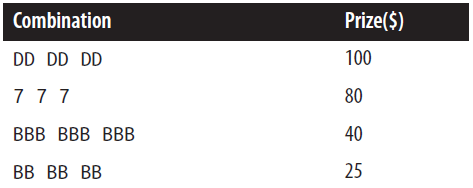

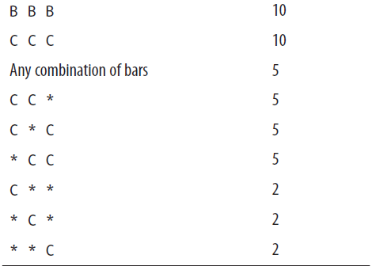

Los programas en R pueden ser guardads como Scripts o como funciones.

Se crearà la funciòn “score” para calcular el premio

```r
#Funcion que simula la slot machine
play <- function() {
  symbols <- get_symbols()
  print(symbols)
  score(symbols)
}
```

Lo ideal es dividir los còdigos en pequeñas tareas para facilitar la programaciòn. hay dos tipos de estas subtareas en R. sequential steps y parallel cases

### Sequential steps

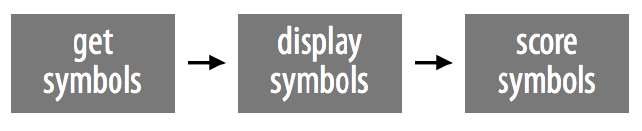

un ejemplo de esto es la funciòn play() que se programò anteriormente

```r
play <- function() {
  # step 1: Genera los sìmbolos
  symbols <- get_symbols()
  # step 2: Muestra los sìmbolos
  print(symbols)
  # step 3: Puntea los sìmbolos
  score(symbols)
}
```

### Parallel Cases

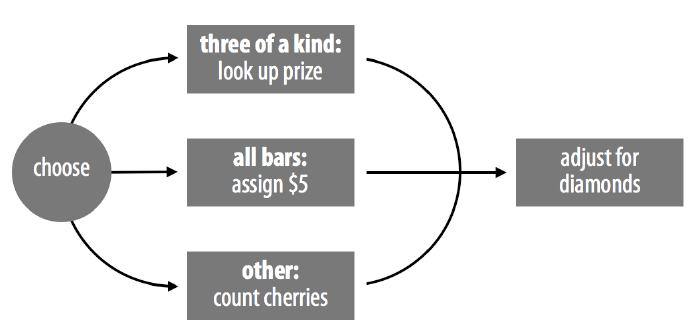

El procesopuede incluir ambos tipos de subtareas

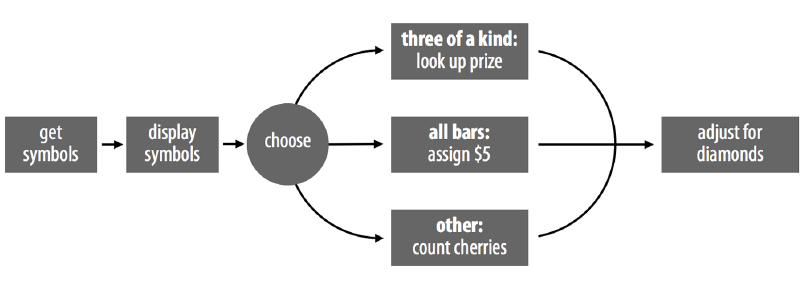

### if Statements

Las subtareas en paralelos se crearàn con la ayuda de los condiocionales. La lògica de los condicionales en R es parecido a lo siguiente:

`if (this) {`

`that`

`}`

```r
#Si num es negativo entonces el valor es multiplicado por -1
num=-5
if (num < 0) {
  num <- num * -1
}
```

```r
num <- -1
if (num < 0) {
  print("num is negative.")
  print("Don't worry, I'll fix it.")
  num <- num * -1
  print("Now num is positive.")
}
num
```

```r
  x <- 1
  if (3 == 3) {
  x <- 2
}
x
```

```r
x <- 1
  if (TRUE) { #La condiciòn ya de por sì es verdadera asì que no necesita evaluarla y automàticamente se entrarà al còdigo del condicional
  x <- 2
}
x
```

```r
x <- 1
if (x == 1) {
  x <- 2
  if (x == 1) {
    x <- 3
  }
}
x
```